# 贷款风险评估

## **问题背景**

[Lending Club](https://www.lendingclub.com/)是美国的一个贷款中介服务提供商。在这个Lab中，我们将利用该公司在网上公开的[P2P贷款](https://en.wikipedia.org/wiki/Peer-to-peer_lending)数据，建立一个贷款的风险分析模型。

## **数据来源说明**

这个Lab中的数据为Lending Club原始数据的简化版，主要使用了贷款前可以获得的用户信息以及每笔贷款的描述信息，你可以直接从[Lending Club](https://www.lendingclub.com/info/download-data.action)或从[Kaggle](https://www.kaggle.com/wendykan/lending-club-loan-data)上下载到更完整的数据

## **目标**

使用贷前可掌握的客户信息，建立模型预判某笔贷款风险是否存在风险

> *注:*
> - 由于中国的信用体系与美国有一定的差异，因此本Lab未考虑信用相关特征(你可以用完整数据集尝试，比较容易获得不错的效果)
> - 本数据集仅为个人P2P贷款数据，同时鉴于行业情况的差异，以及所能获得数据的差异，本Lab的处理手段仅供参考

## I. 读入数据

### 工具导入

首先我们导入探索性数据分析阶段需要用到的工具，我们在这个Lab中还将使用plotly，这是一个可交互的可视化解决方案。plotly正变得越来越流行，我们将用它来尝试可视化地理信息

```python
import numpy as np
import pandas as pd
import matplotlib.pyplot as plt
import seaborn as sns

# 使用plotly进行可视化
import plotly.graph_objs as go
from plotly.offline import init_notebook_mode, iplot
init_notebook_mode()


%matplotlib inline
%config InlineBackend.figure_format = 'retina'
```

## II. 特征概览

### 2.1 读取数据

```python
data = pd.read_csv('./input/lending-club-loan-data/loan_less.csv', low_memory=False)
```

```python
data.info()
```

```
<class 'pandas.core.frame.DataFrame'>
RangeIndex: 200000 entries, 0 to 199999
Data columns (total 13 columns):
loan_amnt         200000 non-null int64
term              200000 non-null object
int_rate          200000 non-null float64
grade             200000 non-null object
emp_length        187007 non-null object
home_ownership    200000 non-null object
annual_inc        200000 non-null float64
addr_state        200000 non-null object
purpose           200000 non-null object
zip_code          200000 non-null object
loan_status       200000 non-null object
issue_d           200000 non-null object
dti               199853 non-null float64
dtypes: float64(3), int64(1), object(9)
memory usage: 19.8+ MB
```

### 2.2 以下是这些特征的描述:

| loan_amnt | 贷款人申请的金额，或信用部门修改后的贷款金额 |
| --- | --- |
| term | 贷款时长，可能值为36或60(月) |
| int_rate | 贷款利率 |
| grade | 风险等级 |
| emp_length | 工作年限 |
| home_ownership | 住房情况 |
| annual_inc | 年收入 |
| addr_state | 居住地所在州 |
| purpose | 贷款目的 |
| zip_code | zip code |
| loan_status | 贷款状态 (此为目标特征) |
| issue_d | 贷款日期 |
| dti | 负债比 |

### 2.3 目标特征

#### 各贷款状态的描述

| Current | 正常还款，尚在还款期 |
| --- | --- |
| Fully Paid | 到期完全还清 |
| In Grace Period | 处于宽限期 |
| Default | 还款期间违约 |
| Late | 逾期 |
| Charged Off | 坏账 |

#### 感兴趣的状态

在这个Lab中，我们暂不考虑正在进行的贷款个案，这样一来，我们会剩下一半多的数据:

```python
data=data[~data.loan_status.isin(['Current', 'In Grace Period'])]
data.info()
```

```
<class 'pandas.core.frame.DataFrame'>
Int64Index: 117907 entries, 9 to 199997
Data columns (total 13 columns):
loan_amnt         117907 non-null int64
term              117907 non-null object
int_rate          117907 non-null float64
grade             117907 non-null object
emp_length        110985 non-null object
home_ownership    117907 non-null object
annual_inc        117907 non-null float64
addr_state        117907 non-null object
purpose           117907 non-null object
zip_code          117907 non-null object
loan_status       117907 non-null object
issue_d           117907 non-null object
dti               117879 non-null float64
dtypes: float64(3), int64(1), object(9)
memory usage: 12.6+ MB
```

#### 风险状态

去除上述两种状态后，我们认为不是完全还清的都为有风险的状态，最终我们的目标变量有两种情况:

- 有风险 0
- 无风险 1

它被存储在`ok_loan`变量中

```python
ok_loan_status = ["Fully Paid", "Does not meet the credit policy. Status:Fully Paid"]

# NOTE: https://www.collinsdictionary.com/dictionary/english/grace-period
data['ok_loan'] = (data.loan_status.isin(ok_loan_status)).astype(int)
```

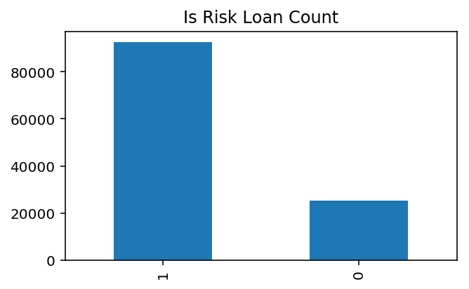

```python
data.ok_loan.value_counts().plot.bar(figsize=(5, 3))
plt.title('Is Risk Loan Count');
```

从上述图示可以看出，有风险的贷款个案其实占少数，这同时意味着，我们将需要处理其类别不均衡的问题

## III. 探索性可视化

### 3.1 地理数据的转换

在这里我们将尝试如何结合地图数据进行可视化，这个数据集中，我们同时有州名以及`zip_code`，其中:

- Plotly直接支持州名代码的地理可视化
- `zip_code`一般能够反映城市数据，网上有很多免费的数据集能够提供`zip_code`与经纬度的映射

```python
# 由于前 3 位相同的zipcode地理位置靠近，我们可以用模糊的填充
data['zip_code'] = data['zip_code'].apply(lambda x : str(x)[:3]+"01")

# 读取一个包含zipcode转经纬的数据集
uszip = pd.read_csv('./input/simplemaps/uszips.csv', usecols=['zip', 'lat', 'lng'], dtype={'zip':np.object})
uszip.rename(columns={'zip':'zip_code'}, inplace=True)

# 合并两个数据集
data = data.merge(uszip, how='left', on='zip_code')
```

```python
show_data = []
layout = dict(title='Risk Rate by State', width=800, height=500, legend=dict(bgcolor='rgba(0,0,0,0)'))


# 数据整理
# 1. 各州贷款个案数
state_count = data.groupby('addr_state')['lat', 'lng'].mean().join(data['addr_state'].value_counts())
# 2. 各州贷款风险占比
state_ok_rate = data.groupby('addr_state')[['ok_loan', 'lat', 'lng']].mean()

# 使用两种plotly可视化
show_data.extend([
            go.Choropleth(
                locations = state_ok_rate.index,
                z = 1 - state_ok_rate.ok_loan,
                name = 'Risk Rate',
                locationmode = 'USA-states',
                colorbar = dict(title = "Risk Rate"),
                geo = 'geo'),

            go.Scattergeo(
                lat = state_count.lat,
                lon = state_count.lng,
                name = 'Count',
                text = state_count.index + ' ' + state_count.addr_state.astype(str),
                marker = dict(size=state_count.addr_state.astype(float)/500, color='lightblue'),
                geo = 'geo')
             ])

layout['geo'] = dict(scope='usa', projection=dict(type='albers usa'))



fig = go.Figure(data=show_data, layout=layout)
iplot(fig)
```

[interactive chart not shown]

> 上图中:
> - 颜色表示该州风险贷款的占比
> - 原点大小表示该州贷款个案数 (进行了一定的缩放)

> 可以看到，加州，德克萨斯州，弗罗里达州，以及纽约州附近地区有最多的贷款个案，但是这些州的风险占比只有略微的差异

### 3.2 用户背景分析

这里将会对用户的背景进行简单的分析，包括

- 职业背景
- 居住信息
- 贷款目的

#### 3.2.1 以下我们将观察各个房屋条件，工作年限不同的群体，以及年收入情况

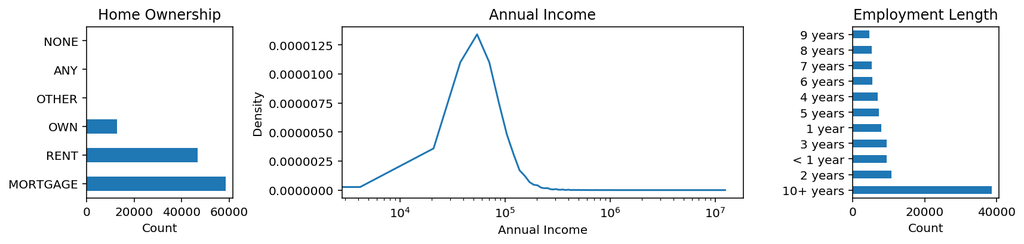

```python
plt.figure(figsize=(12,3))
ax1 = plt.subplot2grid((1, 4), (0, 0))
ax2 = plt.subplot2grid((1, 4), (0, 1), colspan=2)
ax3 = plt.subplot2grid((1, 4), (0, 3))
# 房屋情况
data['home_ownership'].value_counts().plot(kind='barh', ax=ax1)
ax1.set_title('Home Ownership')
ax1.set_xlabel('Count')

# 年收入
data['annual_inc'].plot.kde(ax=ax2)
ax2.set_xscale('log')
ax2.set_title('Annual Income')
ax2.set_xlabel('Annual Income')

# 工作年限
data['emp_length'].value_counts().plot(kind='barh', ax=ax3)
ax3.set_title('Employment Length')
ax3.set_xlabel('Count')

# 紧密作图
plt.tight_layout()
```

#### 3.2.2 以下我们将利用[堆叠面积图](https://vis.baidu.com/chartusage/stackedarea/)来观察贷款金额和居住信息，贷款目的的关系

首先，这里我们会先整理一个函数，它会为我们作出随着时间，上述变量的变化情况

```python
from pandas.plotting import register_matplotlib_converters
register_matplotlib_converters()

def stack_show(x_col, val_col, hue_col, r=3, ax=None, bl='zero'):

    target = data.pivot_table(index=x_col,
                          values=val_col,
                          columns=hue_col,
                          aggfunc=np.mean,
                          fill_value=0)

    data_r = target.rolling(r).mean()
    _ax = ax
    if _ax == None:
        _, _ax = plt.subplots(1, 1, figsize=(8, 3))
    _ax.stackplot(data_r.index, data_r.values.T, labels=data_r.columns, alpha=0.6, baseline=bl, colors=sns.color_palette("tab20"));
    _ax.legend(loc=2)
    return _ax
```

首先，是房屋信息

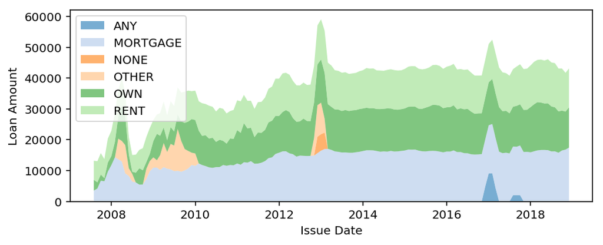

```python
ax = stack_show(pd.to_datetime(data.issue_d), 'loan_amnt', 'home_ownership')
ax.set_ylabel('Loan Amount');
ax.set_xlabel('Issue Date');
```

> 就上图看来，房屋按揭群体的贷款额会稍大于其他两个主流群体，三个主流群体的贷款额变化趋势基本相同

而后，我们来看一下贷款目的

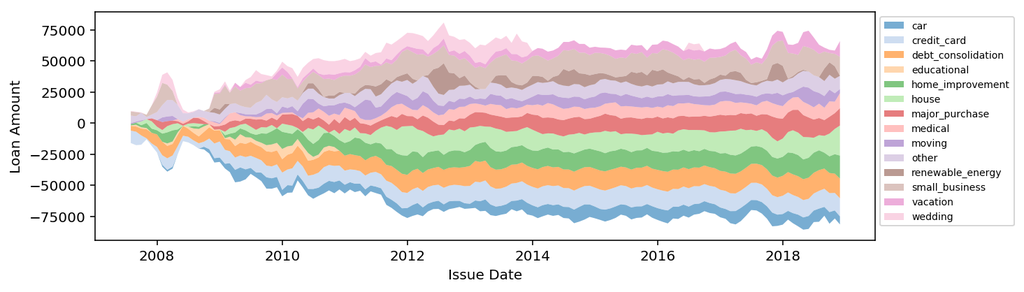

```python
_, ax = plt.subplots(1,1, figsize=(10, 3))
stack_show(pd.to_datetime(data.issue_d), 'loan_amnt', 'purpose', ax=ax, r=3, bl='wiggle')
ax.legend(bbox_to_anchor=(1, 1), loc=2, ncol=1, fontsize=7)
ax.set_ylabel('Loan Amount');
ax.set_xlabel('Issue Date');
```

> - 小型产业，住房相关的贷款金额更高
> - 2008之后到2012，各个需求的贷款额都在逐渐上升
> - 其中用于房屋的贷款在2011年后期有小的”爆发“
> - 用于教育的贷款在 2011 年左右则逐渐收缩，用于婚礼的贷款在 2014 年前后也逐渐收缩

## IV. 特征处理

### 4. 1 缺失值的处理

这里的流程为:

- 检查数据情况
- 根据数据缺失的情况，按需处理

```python
# 进行处理前，我么先整理出X和y，然后在此之上修改整理
X = data.drop(['issue_d', 'zip_code', 'loan_status', 'ok_loan'], axis=1)
y = data['ok_loan']
```

```python
X.info()
```

```
<class 'pandas.core.frame.DataFrame'>
Int64Index: 117907 entries, 0 to 117906
Data columns (total 12 columns):
loan_amnt         117907 non-null int64
term              117907 non-null object
int_rate          117907 non-null float64
grade             117907 non-null object
emp_length        110985 non-null object
home_ownership    117907 non-null object
annual_inc        117907 non-null float64
addr_state        117907 non-null object
purpose           117907 non-null object
dti               117879 non-null float64
lat               86242 non-null float64
lng               86242 non-null float64
dtypes: float64(5), int64(1), object(6)
memory usage: 11.7+ MB
```

#### `lat`, `lon`, `dti`的处理

这里需要处理的是`lat`, `lon`, 以及`dti`, 我们将使用它们的均值进行填充

```python
X.lat = X.lat.fillna(data.lat.mean())
X.lng = X.lat.fillna(data.lng.mean())
X.dti = X.dti.fillna(data.dti.mean())
```

### 4.2 类别型的特征的数值编码

接下来，我们会将工作年限进行编码:

- 将小于 1 年编码为数值 0
- 将大于等于 10 年编码为 10

当然这样编码有一定的局限性，你也可以用你喜欢的方式进行编码哦

```python
X.emp_length.replace({'< 1 year': '0 year', '10+ years': '10 years'}, inplace=True)
X.emp_length.fillna('0 year', inplace=True)
X.emp_length = X.emp_length.apply(lambda x: x.split()[0]).astype(int)
```

然后我们对其他的类目型特征进行Label Encoding

[Label Encoding](http://scikit-learn.org/stable/modules/generated/sklearn.preprocessing.LabelEncoder.html)的效果为:

- 原特征: `['cat', 'dog', 'ant', 'zebra', 'cat', 'elephant'...]`
- 编码后: `[1, 2, 0, 4, 1, 3]` (字符排序较小的将被分配较小的数字)

```python
from sklearn.preprocessing import LabelEncoder


cols = X.select_dtypes('object').columns
for col in cols:
    print(col)
    X[col] = LabelEncoder().fit_transform(X[col])
```

```
term
grade
home_ownership
addr_state
purpose
```

我们观察一下处理后的数据

```python
X.info()
```

```
<class 'pandas.core.frame.DataFrame'>
Int64Index: 117907 entries, 0 to 117906
Data columns (total 12 columns):
loan_amnt         117907 non-null int64
term              117907 non-null int64
int_rate          117907 non-null float64
grade             117907 non-null int64
emp_length        117907 non-null int64
home_ownership    117907 non-null int64
annual_inc        117907 non-null float64
addr_state        117907 non-null int64
purpose           117907 non-null int64
dti               117907 non-null float64
lat               117907 non-null float64
lng               117907 non-null float64
dtypes: float64(5), int64(7)
memory usage: 11.7 MB
```

### 4.3 拆分数据集

在以下代码框，我们会将数据拆成训练集以及测试集

```python
from sklearn.model_selection import train_test_split
X_tr, X_t, y_tr, y_t = train_test_split(X.values, y.values, test_size=0.3)
```

### 4.4 数据缩放

```python
from sklearn.preprocessing import MinMaxScaler

mms = MinMaxScaler()
X_tr = mms.fit_transform(X_tr)

X_t = mms.transform(X_t)
```

### 4.5 重新采样

还记得我们提到过，这个数据存在数据不均衡的问题吗，现在我们就利用[imblearn](https://imbalanced-learn.readthedocs.io/en/stable/over_sampling.html#a-practical-guide)来解决这个问题。

我们将对数据量少的样本进行过采样，也就是随机选取已有的少类别数据，将其加到原数据集中，使得正负两种类别的数据量一致

```python
from imblearn.over_sampling import RandomOverSampler
rdmos = RandomOverSampler(random_state=0)
X_tr, y_tr = rdmos.fit_resample(X_tr, y_tr)
```

```python
y_tr.mean()
```

```
0.5
```

可以看到，数据量一致

## V. 评价指标

在建立预测模型之前，首先确定我们的评价指标，甚至作好封装是一个不错的做法。在本Lab中，我们将：

- 计算准确率，accuracy
- 计算[Precision, Recall, 以及F-score](https://blog.argcv.com/articles/1036.c)
- 可视化ROC，计算AUC [参考](https://zh.wikipedia.org/wiki/ROC%E6%9B%B2%E7%BA%BF)

```python
from sklearn.metrics import precision_recall_fscore_support, roc_curve, roc_auc_score, confusion_matrix, accuracy_score

def performance_summary(y_true, y_pred, y_score=None):
    # 计算所有的数值指标
    numerics = {}
    numerics['auc'] = roc_auc_score(y_true, y_pred)
    numerics['precision'], numerics['recall'], numerics['f1'], _ = precision_recall_fscore_support(y_true, y_pred, average='binary')
    numerics['acc'] = accuracy_score(y_true, y_pred)

    basic = pd.DataFrame(numerics, index=[0])
    cm = confusion_matrix(y_true, y_pred)


    # 可视化
    _, axes = plt.subplots(1, 3, figsize=(12, 3))

    # 1. 基础的几个数值指标
    basic.T.plot.barh(xlim=(0, 1), legend=False, ax=axes[0], alpha=0.6)
    for p in axes[0].patches:
        axes[0].annotate('%.4f'%p.get_width(), (p.get_width()-0.2, p.get_y()+0.2), color='w')
    axes[0].set_title('Basic')

    # 2. 混淆矩阵
    sns.heatmap(cm, annot=cm/cm.sum(), ax=axes[1], cmap="Blues", square=True, alpha=0.6, cbar=None)
    axes[1].set_title('Confusion Matrix')


    # 3. ROC
    try:
        rc = roc_curve(y_true, y_score, pos_label=1)
        axes[2].plot(rc[0], rc[1], linewidth=2, alpha=.6)
        axes[2].fill_between(rc[0], rc[1], 0, alpha=0.3, color=sns.color_palette(palette='Blues'))
        axes[2].set_title('AUC = %.2f'%numerics['auc'])
    except:
        return
```

## VI. 模型

### 逻辑回归

现在我们就可以尝试建立我们的预测模型了，我们先尝试使用我们熟悉的逻辑回归进行尝试，让我们导入它，并尝试进行预测，这里我们先快速建立模型，并测试我们的评价功能

```python
from sklearn.linear_model import LogisticRegression
lr = LogisticRegression(random_state=42, solver='liblinear').fit(X_tr, y_tr)
y_p = lr.predict(X_t)
y_s = lr.decision_function(X_t)
```

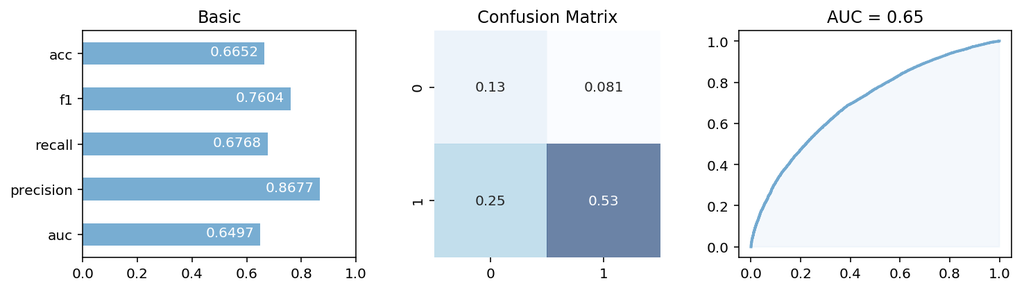

```python
performance_summary(y_t, y_p, y_s)
```

### LightGBM

LightGBM是微软的一个基于树模型的梯度提升模型([Gradient Boosting](https://en.wikipedia.org/wiki/Gradient_boosting))框架。在数据竞赛上是一个颇受欢迎的模型，以下我们将尝试这个模型，并展示如何去使用[随机搜索](https://yq.aliyun.com/articles/68266)进行参数调整

```python
import lightgbm as lgb
from sklearn.model_selection import RandomizedSearchCV

rdm_obj = RandomizedSearchCV(estimator=lgb.LGBMClassifier(),
                             param_distributions=dict(learning_rate=np.random.uniform(0.01,0.05, 100),
                                                      n_estimators=np.arange(20, 420, 20)),
                             n_iter=20,
                             n_jobs=-1,
                             cv=5,
                             scoring='neg_log_loss',
                             verbose=True)
```

```python
rdm_obj = rdm_obj.fit(X_tr, y_tr)
```

```
Fitting 5 folds for each of 20 candidates, totalling 100 fits
```

```
[Parallel(n_jobs=-1)]: Using backend LokyBackend with 4 concurrent workers.
[Parallel(n_jobs=-1)]: Done  42 tasks      | elapsed:  1.3min
[Parallel(n_jobs=-1)]: Done 100 out of 100 | elapsed:  2.5min finished
```

```python
clf = rdm_obj.best_estimator_
y_p = clf.predict(X_t)
y_s = clf.predict_proba(X_t)[:,1]
```

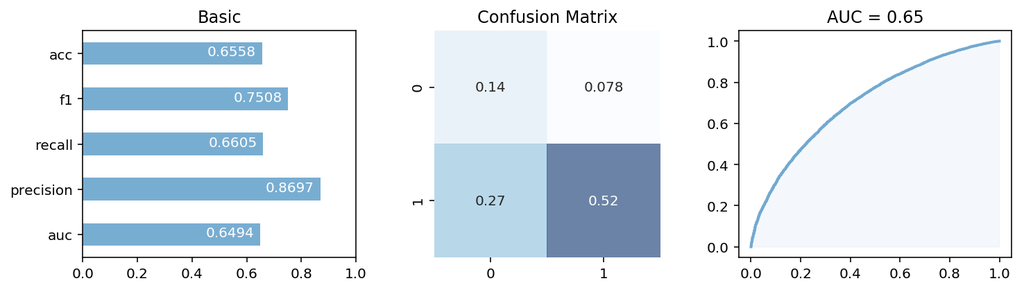

```python
performance_summary(y_t, y_p, y_s)
```

## VII. 结论

至此，你已经对这个数据集有了比较清晰的认识，我们建立了一个比较简单的分类器来判别贷款是否有风险。它能够一定程度上解决贷前风险预测的问题。但是往往问题定义的不同，得到的结果很可能不同。这里你可以尝试:

- 目前我们将无风险的贷款记为正类，请思考，如果将存在风险的贷款记为正类，recall 和 precision 的结果是一样的吗？它们的含义是否会发生变化， 哪种定义更加合适？
- 如果不处理数据不均衡，得到的结果会如何变化？
- 本Lab仅提取了部分特征，尝试探索完整的数据集，尝试更多的特征，它们能否提高你模型的表现？
- 你还能从这个数据集中提出更多别的问题吗？

你还能到[Kaggle](https://www.kaggle.com/wendykan/lending-club-loan-data)上，查看更多数据爱好者们如何去探索这个数据哦